# Lecture 2.C: Partialling-out and Post-Selection/Regularization Inference for IV Models

VC

June 20, 2016

# Two equations linear IV model

The canonical linear structural equation model of Econometrics: $\begin{aligned} Y &= \alpha_1 D + \alpha_2' W + U, \quad U \perp (W',Z')', \\ D &= \beta_1 Z + \beta_2' W +V, \quad V \perp (W', Z')', \end{aligned}$

Context is given e.g. by Acemoglu, Johnson, Robinson (2001), where

- Y is log GDP;
- D is a measure of Protection from Expropriation, a proxy for quality of insitutions;
- Z is the log of Settler’s mortality;
- W are geographical variables (atitute, latitude squared, continent dummies as well as interactions)

# Partialling out

- Variables $Y$ and $D$ are endogenous, $W$ are controls, involving transformations of raw controls, $Z$ is the instrumental variable.
- Application of the partialling out operator in population to both sides of each of the equations in gives us a much simpler system of equations:

$\begin{array}{l} \tilde Y = \alpha_1 \tilde D + U, \quad U \perp \tilde Z, \\ \tilde D = \beta_1 \tilde Z + V, \quad V \perp \tilde Z. \end{array}$

- The target parameter $\alpha_1$ is identified by IV of $\tilde Y$ on $\tilde D$ using $\tilde Z$ as the instrument.
- If $W$’s are high-dimensional, we will rely on Lasso/Post-lasso or other high-quality techniques to partial out $W$’s.

# Analyze AJR (2001) | R

```r
library(hdm)
```

- First we process data:

```r
data(AJR);
y = AJR$GDP;
d = AJR$Exprop;
z = AJR$logMort
w = model.matrix(~ -1 + (Latitude + Latitude2 + Africa +
                   Asia + Namer + Samer)^2, data=AJR)
dim(w)
```

```
## [1] 64 21
```

# Analyze AJR (2001) |R

- We can first try to use OLS for partialling out.
- We don’t expect this to work well since $X$’s are high-dimensional.

```r
fmla.y = GDP ~ (Latitude + Latitude2 + Africa + Asia + Namer + Samer)^2
fmla.d = Exprop ~ (Latitude + Latitude2 + Africa + Asia + Namer + Samer)^2
fmla.z = logMort ~ (Latitude + Latitude2 + Africa + Asia + Namer + Samer)^2
rY = lm(fmla.y, data = AJR)$res
rD = lm(fmla.d, data = AJR)$res
rZ = lm(fmla.z, data = AJR)$res
ivfit.lm = tsls(y=rY,d=rD, x=NULL, z=rZ, intercept=FALSE)
res = cbind(ivfit.lm$coef, ivfit.lm$se)
colnames(res) = c("est", "se")
print(res,digits=3)
```

```
##     est   se
## d1 1.27 1.73
```

- We see that the estimates exhibit large standard errors (they should in fact be larger, see recent work of Newey).
- This is expected because dimension of $X$ is quite large, comparable to the sample size.

# Analyze AJR (2001) | R

- Then we estimate an IV model with Lasso-based selection/regularization of $X$:

```r
options(warn=-1)
AJR.Xselect = rlassoIV(x=w, d=d, y=y, z=z, select.X=TRUE, select.Z=FALSE)
# note that X plays the role of W
```

- Then we obtain point estimates and standard errors:

```r
summary(AJR.Xselect)
```

```
## [1] "Estimation and significance testing of the effect of target variables in the IV regression model"
##    coeff.   se. t-value  p-value
## d1  0.771 0.203   3.798 0.000146 ***
## ---
## Signif. codes:  0 '***' 0.001 '**' 0.01 '*' 0.05 '.' 0.1 ' ' 1
```

- Using these we can then obtain confidence intervals:

```r
confint(AJR.Xselect)
```

```
##        2.5 %   97.5 %
## d1 0.3731934 1.168885
```

## What is this procedure doing?

- The above procedure approximates the partialling out in population:
- In essence, it approximately partials out $W$ from $Y$, $D$ and $Z$ using Post-Lasso and applies the 2SLS to the residualized quantities.
- Ref: Chernozhukov, Hansen, Spinder (ARE, 2015), which also covers selection/regularizaiont of both $W$ and $Z$, in cases where $Z$ is high-dimensional.

# What is this procedure doing?

- Partialling out by (pos) Lasso

```r
rY = rlasso(fmla.y, data = AJR)$res
rD = rlasso(fmla.d, data = AJR)$res
rZ = rlasso(fmla.z, data = AJR)$res
ivfit.lasso = tsls(y=rY,d=rD, x=NULL, z=rZ, int=FALSE)
res= cbind(ivfit.lasso$coef, ivfit.lasso$se)
colnames(res) = c("est", "se")
print(res, digits=3)
```

```
##      est    se
## d1 0.771 0.203
```

- This is what command rlassoIV() is doing.
- In comparison to OLS-based partialling-out, we see precision is improved by doing selection/regularization of $W$’s

# Summary

```r
library(xtable)
table<- matrix(0, 2, 2)
table[1,1]<- ivfit.lm$coef
table[1,2]<- sqrt(ivfit.lm$vcov)
table[2,1]<- ivfit.lasso$coef
table[2,2]<- sqrt(ivfit.lasso$vcov)
colnames(table)<- c("est", "se")
rownames(table)<- c("IV no selection", "IV double lasso")
tab<- xtable(table, digits =2)
```

```r
print(tab, type="html")
```

|  | est | se |
| --- | --- | --- |
| IV no selection | 1.27 | 1.73 |
| IV double lasso | 0.77 | 0.20 |

- Traditional IV method done with flexibly geographical controls is very noisy
- The “New” IV method provides a less noisy estimate, which is theoreticall justified.

# Experiments | Let’s try regression trees and random forests next… why not?

- regression trees:

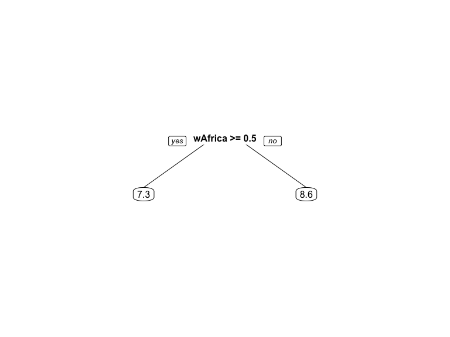

```r
library(rpart)
library(rpart.plot)
  trees  = rpart(y~w)
  bestcp = trees$cptable[which.min(trees$cptable[,"xerror"]),"CP"]
  ptree  = prune(trees,cp=bestcp)
 rY  <-  y-predict(ptree,data=x)
prp(ptree)
```

# Experiments | Tree-based partialling out

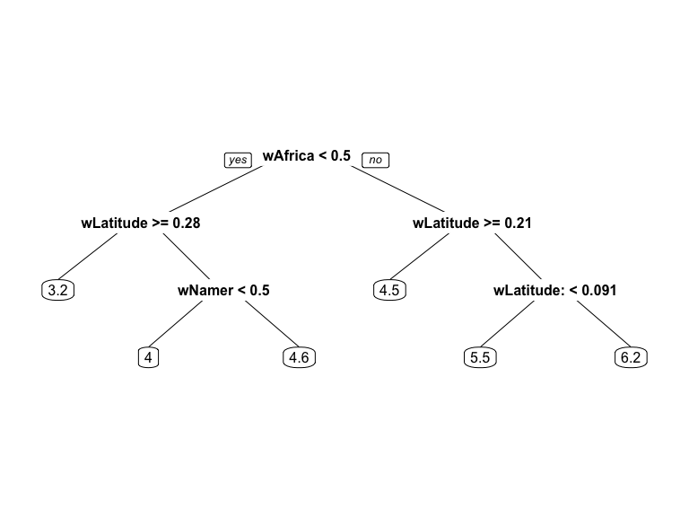

```r
  trees          <- rpart(z~w)
  bestcp        <- trees$cptable[which.min(trees$cptable[,"xerror"]),"CP"]
  ptree          <- prune(trees,cp=bestcp)
rZ<- z - predict(ptree, data=w)
prp(ptree)
```

# Experiments | Tree-based partialling out

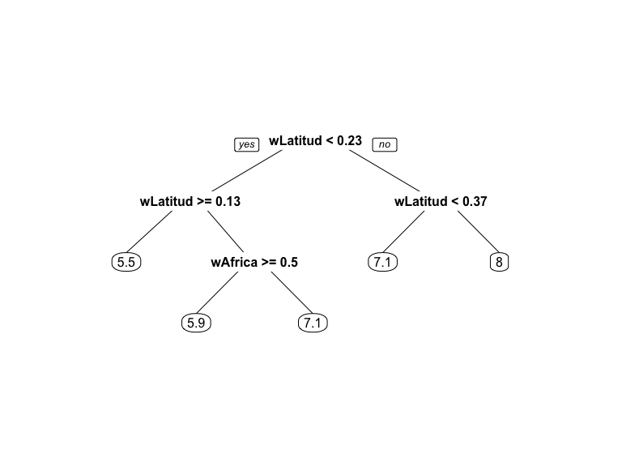

```r
 trees          <- rpart(d~w)
  bestcp        <- trees$cptable[which.min(trees$cptable[,"xerror"]),"CP"]
  ptree          <- prune(trees,cp=bestcp)

rD<- d - predict(ptree, data=w)
prp(ptree)
```

# Experiments | Tree-based partialling out

```r
ivfit.rt<- tsls(y=rY,d=rD, x=NULL, z=rZ,int=FALSE)
```

# Experiments | Forest-based partialling out

```r
library(randomForest)
set.seed(1)
rY  <-  y-randomForest(w,y)$predicted
set.seed(1)
rD  <-  d-randomForest(w,d)$predicted
set.seed(1)
rZ  <-  z-randomForest(w,z)$predicted
ivfit.rf<- tsls(y=rY,d=rD, x=NULL, z=rZ,int=FALSE)
```

# Experiments | Comparisons

```r
library(xtable)
table<- matrix(0, 4, 2)
table[1,1]<- ivfit.lm$coef
table[1,2]<- sqrt(ivfit.lm$vcov)
table[2,1]<- ivfit.lasso$coef
table[2,2]<- sqrt(ivfit.lasso$vcov)
table[3,1]<- ivfit.rt$coef
table[3,2]<- sqrt(ivfit.rt$vcov)
table[4,1]<- ivfit.rf$coef
table[4,2]<- sqrt(ivfit.rf$vcov)
colnames(table)<- c("est", "se")
rownames(table)<- c("IV no selection", "IV double lasso", "IV double tree", "IV double Forest")
tab<- xtable(table, digits =2)
```

# Experiments | Comparisons

- print results

```r
print(tab, type="html")
```

|  | est | se |
| --- | --- | --- |
| IV no selection | 1.27 | 1.73 |
| IV double lasso | 0.77 | 0.20 |
| IV double tree | 1.42 | 1.17 |
| IV double Forest | 0.94 | 0.48 |

- reg trees and random forests (with default options) seem to overfitting

# Experiments | Do the trees and random forests overfit?

to demonstrate the point that reg trees overfit

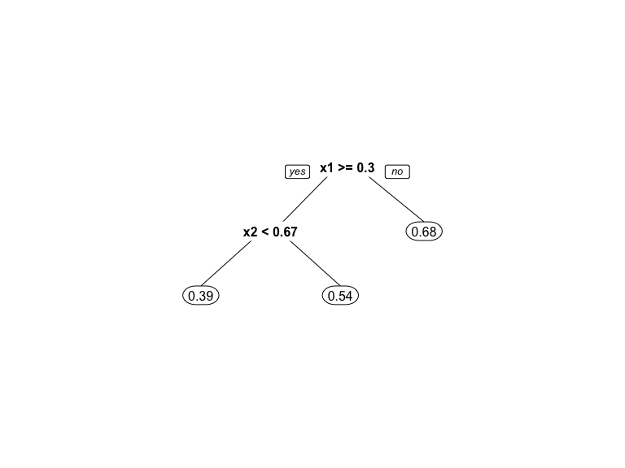

```r
set.seed(1)
x<- cbind(runif(30), runif(30))
y<- runif(30)
  trees          <- rpart(y~x)
  bestcp        <- trees$cptable[which.min(trees$cptable[,"xerror"]),"CP"]
  ptree          <- prune(trees,cp=bestcp)
  prp(ptree)
```

```r
py <-  predict(ptree)
```

# Experiments | Do the trees and random forests overfit?

```r
library(glmnet)
```

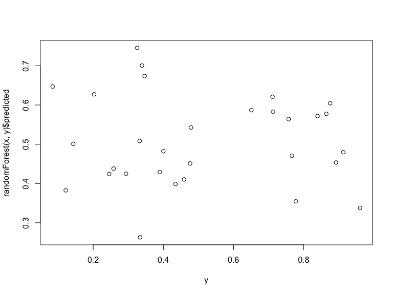

```r
ov.rt<- var(py)/var(y)
py  <-  randomForest(x,y)$predicted
plot(y,randomForest(x,y)$predicted)
```

```r
ov.rf<- var(py)/var(y)
py  <-  y-rlasso(y~x)$res
ov.rlasso<- var(py)/var(y)
py<- predict(cv.glmnet(x,y),newx=x)
ov.glmnet.lasso<- var(py)/var(y)
```

# Experiments | Do the trees and random forests overfit?

- process results into a table

```r
library(xtable)
table<- matrix(0, 4, 1)
table[1,1]<- ov.rt
table[2,1]<- ov.rf
table[3,1]<- ov.rlasso
table[4,1]<- ov.glmnet.lasso
colnames(table)<- c("% overfit")
rownames(table)<- c("reg tree", "forest", "(post) rlasso", "cv glmnet lasso")
tab<- xtable(table, digits =2)
```

# Experiments | Do the trees and random forests overfit?

- print results

```r
print(tab, type="html")
```

|  | % overfit |
| --- | --- |
| reg tree | 0.22 |
| forest | 0.17 |
| (post) rlasso | 0.00 |
| cv glmnet lasso | 0.00 |

- (default) reg trees and random forests seem to overfitting;

so either need to better tune them or use separate sample to avoid estimation